# Bolas_Lab13_SpatialDependence

Ellie

May 24, 2017

# Spatial Dependence- Spatial Lag and Spatial Error Models

# Get to Know Data

```r
library(maptools)
library(rgdal)
library(raster)
library(latticeExtra)
datapath<-"C:/Users/ebola/Google Drive/Git/GEO200CN/data/ROI"
#ROI <- readOGR(dsn=datapath, layer = "geo200cn_ROI") #this makes the box 32-bit instead of 64-bit. The data originally had a 64-bit box, which R can't read. the way to learn if it is wrong is to do str, which i should always do with data!:
#str(ROI@data) gives me variables, some of which have numbers but are called factors. that is what tells me it's pulling things in as strings, rather than numbers. I can also tell that the numbers are small, so I don't actually need the 64-bit box

ROI <- readOGR(dsn=datapath, layer = "geo200cn_ROI", integer64 = "allow.loss") #allow.loss lets us let go of the box size and shrink down to 32-bit, which is fine bc these numbers aren't that big and don't need 64-bit
proj4string(ROI) #this is the same as what was written in the given code, so I think it's ok
```

```
## [1] "+proj=robin +lon_0=0 +x_0=0 +y_0=0 +a=6371000 +b=6371000 +units=m +no_defs"
```

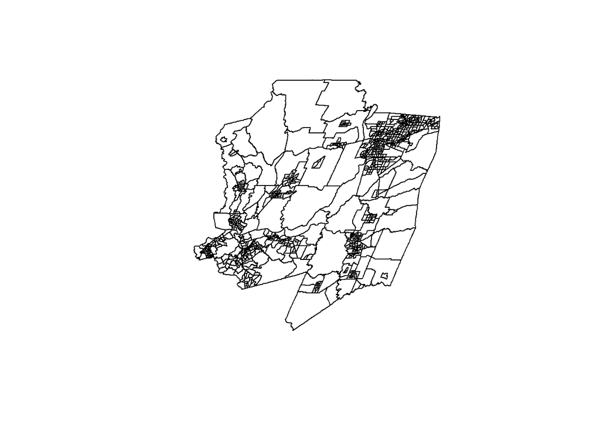

```r
plot(ROI)
```

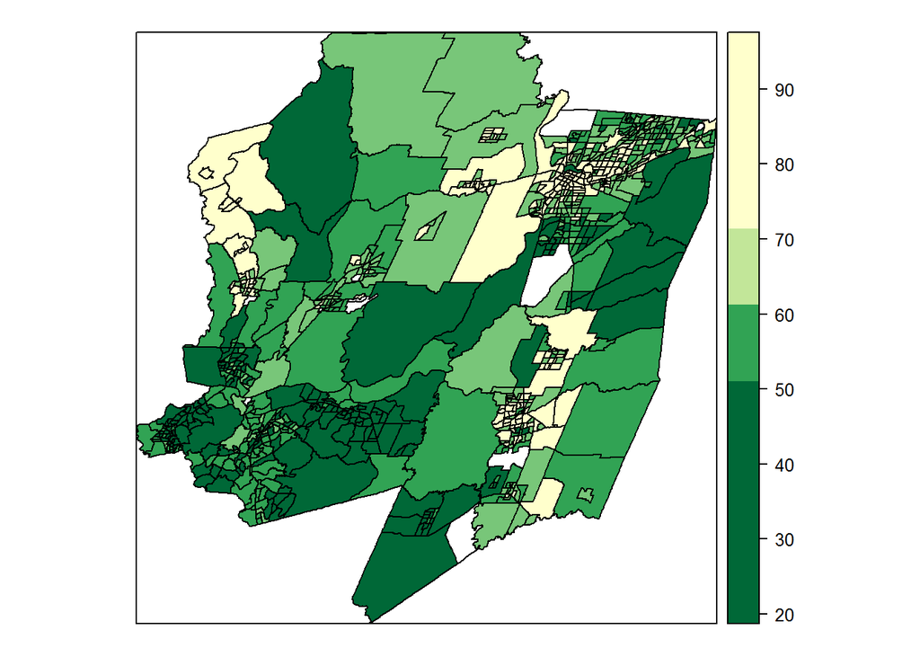

```r
#plot moppl2 to look for patterns with spplot
grps <- 5

brks <- quantile(ROI$moppl2, 0:(grps-1)/(grps-1), na.rm=TRUE) #for quantile, give it a raster object, it computes quantiles from cell values. this is then used with ssplot to assign colors to the quantiles based on the values of moppl2

p <- spplot(ROI, "moppl2", at=brks, col.regions=rev(brewer.pal(grps, "YlGn")), col="transparent" )

p + layer(sp.polygons(ROI))
```

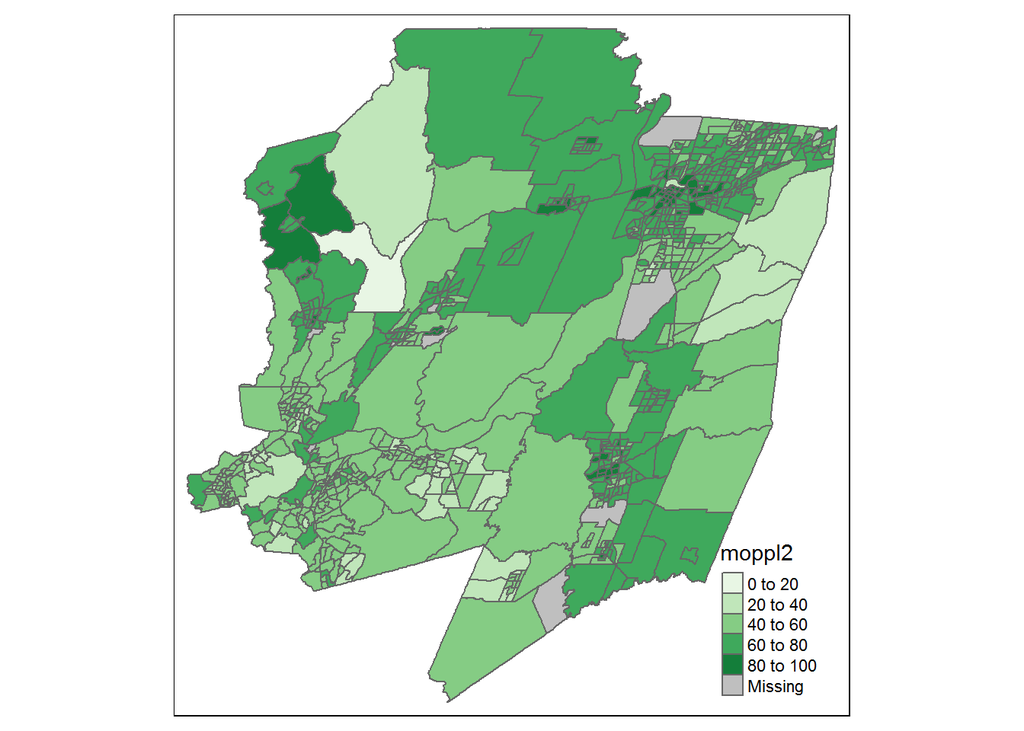

```r
#also plot it with tmap
library (tmap)
qtm (shp=ROI, fill="moppl2", fill.palette="Greens")
```

```r
#remove NAs
ROI <- ROI[!is.na(ROI@data$moppl2),]
```

#### 1. Describe the pattern you see in the data in your own words.

The data does appear to be positively spatial autocorrelated. Generally, areas with a higher value of moppl2 (commute time) are clustered together.

#### Weight’s Matrix

identify nearness

```r
library(spdep)
xy <- coordinates(ROI)
nb2500 <- dnearneigh(xy, 0, 2500)
#dnearneigh finds neighbors by euclidean distance between upper and lower bounds. 1st argument is matrix of points or spatialpoints object; 2nd arg, d1= lower distance; 3rd arg, d2 = upper distance; row.names= region ids; longlat, if true, measure in km, if false, take values from the object
w2500 <- nb2listw(nb2500, zero.policy=TRUE) #gives spatial weights to the neighbors list. zero.policy=true means there can be zero-length weights vectors

print(w2500, zero.policy=TRUE)
```

```
## Characteristics of weights list object:
## Neighbour list object:
## Number of regions: 829
## Number of nonzero links: 4454
## Percentage nonzero weights: 0.6480987
## Average number of links: 5.372738
## 107 regions with no links:
## 8 24 25 26 30 37 73 107 257 258 259 296 297 299 322 326 327 353 354 356 361 364 374 375 376 380 382 390 391 392 393 395 396 397 411 423 424 425 427 428 436 437 442 477 478 479 480 481 501 502 509 513 521 524 526 527 528 529 545 546 547 548 549 555 562 574 584 585 618 623 632 633 634 635 648 653 6…
##
## Weights style: W
## Weights constants summary:
##     n     nn  S0       S1     S2
## W 722 521284 722 340.8153 2975.7
```

#### 2. a) On average how many neighbors does a census tract have?

Each census tract has approximately 5 neighbors.

#### b) how many census tracts have no neighbors?

107 tracts have no neighbors

#### Now can calculate the Moran’s I [remember you could also use Monte Carlo calculations with moran.mc()].

#### 3. provide an interpretation of the results.

```r
MORmoppl2 <-  moran.test (ROI$moppl2, w2500, zero.policy=TRUE)
MORmoppl2
```

```
##
##  Moran I test under randomisation
##
## data:  ROI$moppl2
## weights: w2500
##
## Moran I statistic standard deviate = 23.114, p-value < 2.2e-16
## alternative hypothesis: greater
## sample estimates:
## Moran I statistic       Expectation          Variance
##      0.5879493741     -0.0013869626      0.0006500874
```

The Moran’s I is positive, which signifies positive autocorrelation. The statistic itself is greater than 0.3, indicating that the data is highly autocorrelated, and the pvalue is less than 0.05, indicating that this is a statistically significant result.

# Regression Analysis

## OLS Model

```r
OLSlm <- lm(moppl2~ecppl1 + hsppl1 + ecplc1 + enplc4, data=ROI)
summary (OLSlm) #this is fixed now, but the code originally broke here: it should only do 5 intercepts, not unlimited intercepts. This tells us that it thinks that these variables are not numberic, reading them in as strings (factors), but is trying to turn them into one. That's why it's better to put 9999 for missing data. It thinks it's a character because the data was stored as 64-bit integers which is used to store huge numbers, R doesn't know how to read that, so it reads it as strings. The numbers need to be stored as 32-bit, which is what R likes to read. Need to fix this in readOGR
```

```
##
## Call:
## lm(formula = moppl2 ~ ecppl1 + hsppl1 + ecplc1 + enplc4, data = ROI)
##
## Residuals:
##     Min      1Q  Median      3Q     Max
## -36.290  -7.153   0.143   7.818  37.100
##
## Coefficients:
##              Estimate Std. Error t value Pr(>|t|)
## (Intercept)  6.441628   8.173295   0.788 0.430847
## ecppl1       0.289194   0.076894   3.761 0.000181 ***
## hsppl1      -0.204586   0.021262  -9.622  < 2e-16 ***
## ecplc1       0.012797   0.001111  11.523  < 2e-16 ***
## enplc4       3.212283   0.348335   9.222  < 2e-16 ***
## ---
## Signif. codes:  0 '***' 0.001 '**' 0.01 '*' 0.05 '.' 0.1 ' ' 1
##
## Residual standard error: 11.18 on 824 degrees of freedom
## Multiple R-squared:  0.3149, Adjusted R-squared:  0.3116
## F-statistic:  94.7 on 4 and 824 DF,  p-value: < 2.2e-16
```

#### An important step in evaluating the ﬁt of a model is calculating the residuals, the variance of y not explained by the model. An important assumption is that these will not be produced by a systematic process so they should have a normal distribution ε~N(0,δ2 I), they should also be include being homosketatistic, and independant (or not autocorrelated).

## Plot OLS Diagnostics

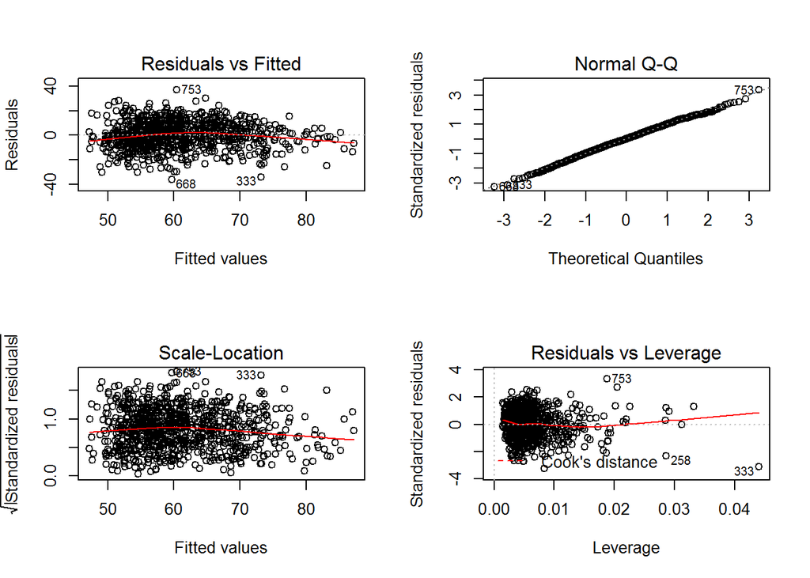

```r
par(mfrow = c(2, 2))
plot (OLSlm)
```

QQ Plot: normal (in a straight line) with some outliers

## Mathmatical OLS Diagnostics:

Breusch-Pagen: tests for heteroscedasticity (non-constant variation in residuals) and Moran’s I: test for residual spatial autocorrelation

```r
#install.packages("lmtest")
library (lmtest)
bptest (OLSlm)
```

```
##
##  studentized Breusch-Pagan test
##
## data:  OLSlm
## BP = 9.4831, df = 4, p-value = 0.05009
```

```r
#BP = 9.4831, df = 4, p-value = 0.05009
lm.morantest (OLSlm, w2500, zero.policy=TRUE)
```

```
##
##  Global Moran I for regression residuals
##
## data:
## model: lm(formula = moppl2 ~ ecppl1 + hsppl1 + ecplc1 + enplc4,
## data = ROI)
## weights: w2500
##
## Moran I statistic standard deviate = 17.535, p-value < 2.2e-16
## alternative hypothesis: greater
## sample estimates:
## Observed Moran I      Expectation         Variance
##     0.4409669549    -0.0041772206     0.0006444474
```

```r
#observed moran's I: 0.4409669549
```

#### 4. Interpret the results from the Breusch-Pagen and Moran’s I test of the residuals

The BP p value=0.05. Because it isn’t less than 0.05, the null hypothesis cannot be rejected, so the residuals are assumed to be homosketatistic (equal variation in residuals.) For the Moran’s I test, the observed Moran’s I is 0.44, which indicates that the residuals are significantly positively autocorrelated.

Use Lagrange Multiplier Test to identify where the strongest spatial dependence is and help choose between using a spatial error or spatial lag model. Focus on signiﬁcance for now represented by the p-value, where the process is to ﬁrst examine the simple tests if either of those are siginifant you start with that form of spatial regession.

```r
lm.LMtests (OLSlm, w2500, zero.policy=TRUE, test='all')
```

```
##
##  Lagrange multiplier diagnostics for spatial dependence
##
## data:
## model: lm(formula = moppl2 ~ ecppl1 + hsppl1 + ecplc1 + enplc4,
## data = ROI)
## weights: w2500
##
## LMerr = 392.1, df = 1, p-value < 2.2e-16
##
##
##  Lagrange multiplier diagnostics for spatial dependence
##
## data:
## model: lm(formula = moppl2 ~ ecppl1 + hsppl1 + ecplc1 + enplc4,
## data = ROI)
## weights: w2500
##
## LMlag = 101.76, df = 1, p-value < 2.2e-16
##
##
##  Lagrange multiplier diagnostics for spatial dependence
##
## data:
## model: lm(formula = moppl2 ~ ecppl1 + hsppl1 + ecplc1 + enplc4,
## data = ROI)
## weights: w2500
##
## RLMerr = 303.24, df = 1, p-value < 2.2e-16
##
##
##  Lagrange multiplier diagnostics for spatial dependence
##
## data:
## model: lm(formula = moppl2 ~ ecppl1 + hsppl1 + ecplc1 + enplc4,
## data = ROI)
## weights: w2500
##
## RLMlag = 12.898, df = 1, p-value = 0.000329
##
##
##  Lagrange multiplier diagnostics for spatial dependence
##
## data:
## model: lm(formula = moppl2 ~ ecppl1 + hsppl1 + ecplc1 + enplc4,
## data = ROI)
## weights: w2500
##
## SARMA = 405, df = 2, p-value < 2.2e-16
```

In our case both of the simple tests are siginifcant and the robust error test is also signiﬁcant, so we’ll start with a spatial error model

## Spatial Error Model

```r
ERRlm <-errorsarlm(moppl2~ecppl1+hsppl1+ecplc1+enplc4, data=ROI, listw=w2500, zero.policy=TRUE)
summary (ERRlm)
```

```
##
## Call:errorsarlm(formula = moppl2 ~ ecppl1 + hsppl1 + ecplc1 + enplc4,
##     data = ROI, listw = w2500, zero.policy = TRUE)
##
## Residuals:
##       Min        1Q    Median        3Q       Max
## -35.60517  -5.19248   0.98437   6.34229  25.17313
##
## Type: error
## Regions with no neighbours included:
##  8 24 25 26 30 37 73 107 257 258 259 296 297 299 322 326 327 353 354 356 361 364 374 375 376 380 382 390 391 392 393 395 396 397 411 423 424 425 427 428 436 437 442 477 478 479 480 481 501 502 509 513 521 524 526 527 528 529 545 546 547 548 549 555 562 574 584 585 618 623 632 633 634 635 648 653 …
## Coefficients: (asymptotic standard errors)
##               Estimate Std. Error z value  Pr(>|z|)
## (Intercept) 14.6864311  7.9825142  1.8398  0.065794
## ecppl1       0.1900096  0.0642855  2.9557  0.003119
## hsppl1      -0.1179787  0.0188958 -6.2437 4.274e-10
## ecplc1       0.0133086  0.0016044  8.2951 < 2.2e-16
## enplc4       2.4928803  0.4785243  5.2095 1.893e-07
##
## Lambda: 0.66306, LR test value: 308.95, p-value: < 2.22e-16
## Asymptotic standard error: 0.028877
##     z-value: 22.962, p-value: < 2.22e-16
## Wald statistic: 527.25, p-value: < 2.22e-16
##
## Log likelihood: -3020.311 for error model
## ML residual variance (sigma squared): 76.58, (sigma: 8.751)
## Number of observations: 829
## Number of parameters estimated: 7
## AIC: 6054.6, (AIC for lm: 6361.6)
```

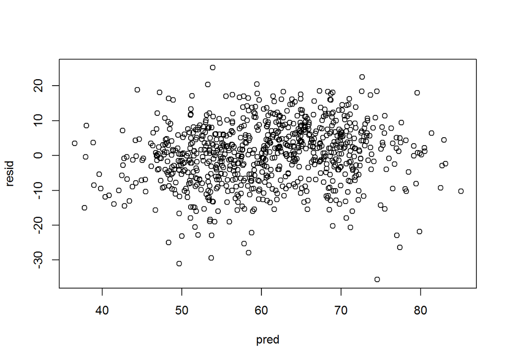

```r
#model residuals
resid <- (resid(ERRlm))
pred = predict(ERRlm, type="response")
plot (pred, resid)
```

```r
bptest.sarlm (ERRlm)
```

```
##
##  studentized Breusch-Pagan test
##
## data:
## BP = 20.452, df = 4, p-value = 0.0004065
```

```r
#BP = 20.452, df = 4, p-value = 0.0004065
#reject null, data heteros
moran.test (resid, w2500, zero.policy=TRUE)
```

```
##
##  Moran I test under randomisation
##
## data:  resid
## weights: w2500
##
## Moran I statistic standard deviate = -1.0231, p-value = 0.8469
## alternative hypothesis: greater
## sample estimates:
## Moran I statistic       Expectation          Variance
##     -0.0274566289     -0.0013869626      0.0006492813
```

```r
#resid are negatively autocorrelated, dispersion, Moran's I:  -0.0274566289
```

## Spatial Lag Model

```r
LAGlm <-lagsarlm(moppl2~ecppl1+hsppl1+ecplc1+enplc4, data=ROI, listw=w2500, zero.policy=TRUE)
summary (LAGlm)
```

```
##
## Call:lagsarlm(formula = moppl2 ~ ecppl1 + hsppl1 + ecplc1 + enplc4,
##     data = ROI, listw = w2500, zero.policy = TRUE)
##
## Residuals:
##        Min         1Q     Median         3Q        Max
## -36.663588  -7.104850  -0.048242   6.949011  31.853863
##
## Type: lag
## Regions with no neighbours included:
##  8 24 25 26 30 37 73 107 257 258 259 296 297 299 322 326 327 353 354 356 361 364 374 375 376 380 382 390 391 392 393 395 396 397 411 423 424 425 427 428 436 437 442 477 478 479 480 481 501 502 509 513 521 524 526 527 528 529 545 546 547 548 549 555 562 574 584 585 618 623 632 633 634 635 648 653 …
## Coefficients: (asymptotic standard errors)
##               Estimate Std. Error z value  Pr(>|z|)
## (Intercept) -0.0381735  7.6866742 -0.0050     0.996
## ecppl1       0.2866419  0.0719839  3.9820 6.833e-05
## hsppl1      -0.1496281  0.0203479 -7.3535 1.932e-13
## ecplc1       0.0107017  0.0010625 10.0726 < 2.2e-16
## enplc4       2.7890010  0.3282495  8.4966 < 2.2e-16
##
## Rho: 0.17115, LR test value: 99.959, p-value: < 2.22e-16
## Asymptotic standard error: 0.016886
##     z-value: 10.136, p-value: < 2.22e-16
## Wald statistic: 102.73, p-value: < 2.22e-16
##
## Log likelihood: -3124.808 for lag model
## ML residual variance (sigma squared): 109.42, (sigma: 10.46)
## Number of observations: 829
## Number of parameters estimated: 7
## AIC: 6263.6, (AIC for lm: 6361.6)
## LM test for residual autocorrelation
## test value: 250.13, p-value: < 2.22e-16
```

```r
#AIC: 6263.6, (AIC for lm: 6361.6)

#AIC of spatialerror: AIC: 6054.6, (AIC for lm: 6361.6)
```

#### 7. a) comare the two spatial models. For example looking at the AIC for both which would you choose as the best model?

The spatial error is the better model because its AIC is lower.